# T5

Jorge Maté Martínez

2023-05-02

```r
# Load the dataset
data <-read.csv("day.csv")

columns = c("cnt")
bikes = data.frame(matrix(nrow=731, ncol=length(columns)))
colnames(bikes) = columns

bikes$cnt = data$cnt # Variable to predict

# Predictors...

bikes$workingday <- data$workingday
bikes$holiday <- data$holiday

# One-hot encoding for season
bikes$season_1 <- ifelse(data$season == 1, 1, 0)
bikes$season_2 <- ifelse(data$season == 2, 1, 0)
bikes$season_3 <- ifelse(data$season == 3, 1, 0)

# Create MISTY and RAIN features
bikes$MISTY <- ifelse(data$weathersit == 2, 1, 0)
bikes$RAIN <- ifelse(data$weathersit == 3 | data$weathersit == 4, 1, 0)

# Denormalize temp, hum, and windspeed
bikes$temp <- data$temp * 47 + -8
bikes$hum <- data$hum * 100
bikes$windspeed <- data$windspeed * 67

# Create days_since_2011 feature
bikes$days_since_2011 <- as.numeric(difftime(as.Date(data$dteday), as.Date("2011-01-01"), units = "days"))
```

```r
library(randomForest)
set.seed(123) # for reproducibility
rf_model <- randomForest(cnt ~ workingday + holiday + season_1 + season_2 + season_3 + MISTY + RAIN + temp + hum + windspeed + days_since_2011, data = bikes)
```

```r
library(pdp)
```

```r
library(ggplot2)
# Create the four partial dependence plots with custom axis labels

days_since_2011_pdp <- partial(rf_model, pred.var = "days_since_2011", plot = TRUE, plot.engine = "ggplot2") +
  ggtitle("Partial dependency plot") +
  xlab("Days Since 2011") +
  ylab("Predicted Bike Counts")

temp_pdp <- partial(rf_model, pred.var = "temp", plot = TRUE, plot.engine = "ggplot2") +
  ggtitle("Partial dependency plot") +
  xlab("Temperature") +
  ylab("Predicted Bike Counts")

hum_pdp <- partial(rf_model, pred.var = "hum", plot = TRUE, plot.engine = "ggplot2") +
  ggtitle("Partial dependency plot") +
  xlab("Humidity") +
  ylab("Predicted Bike Counts")

windspeed_pdp <- partial(rf_model, pred.var = "windspeed", plot = TRUE, plot.engine = "ggplot2") +
  ggtitle("Partial dependency plot") +
  xlab("Wind Speed") +
  ylab("Predicted Bike Counts")
```

## Include Plots

```r
library(gridExtra)
```

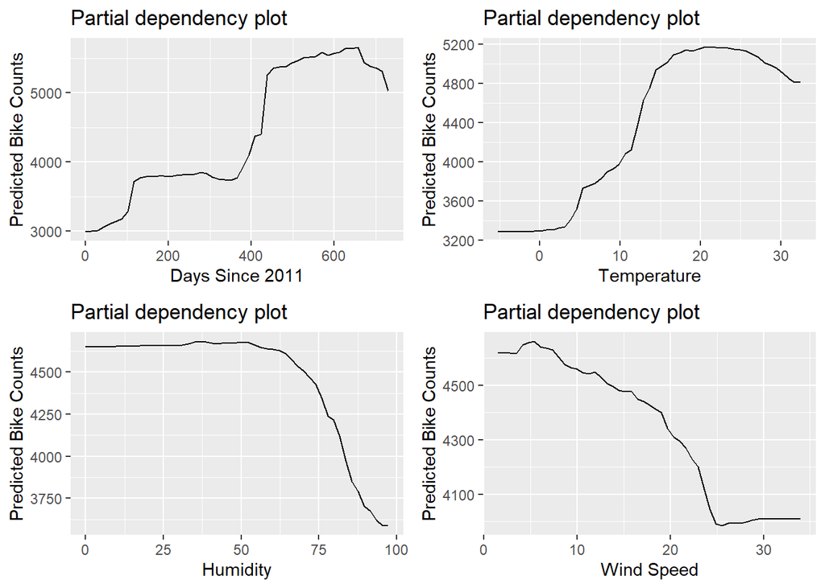

```r
# Combine the four plots into a single plot grid
grid.arrange(days_since_2011_pdp, temp_pdp, hum_pdp, windspeed_pdp, nrow = 2, ncol = 2)
```

Days since 2011 shows that the predicted bike rentals have been steadily increasing since 2011, with a few fluctuations. This suggests that there is a positive relationship between days_since_2011 and the predicted bike rentals.

Temperature shows an inverted U-shaped relationship between temp and the predicted bike rentals, with higher rentals at moderate temperatures (around 20-25 degrees Celsius). This suggests that the relationship between temp and the predicted bike rentals is not linear, but rather has a more complex shape.

```r
# Same random seed, also for reproducibility reasons...
set.seed(123)

# Sample 400 rows at random
sample_index <- sample(nrow(bikes), 400, replace = FALSE)
bike_samples <- bikes[sample_index, ]

# Train the random forest model...
rf_model2 <- randomForest(cnt ~ temp + hum, data = bike_samples)

pdp_data = partial(rf_model2, pred.var = c('temp', 'hum'))
summary(pdp_data)
```

```
##       temp             hum             yhat
##  Min.   :-3.463   Min.   : 0.00   Min.   :1181
##  1st Qu.: 5.167   1st Qu.:23.10   1st Qu.:2537
##  Median :14.517   Median :48.12   Median :4452
##  Mean   :14.517   Mean   :48.12   Mean   :4064
##  3rd Qu.:23.868   3rd Qu.:73.15   3rd Qu.:5281
##  Max.   :32.498   Max.   :96.25   Max.   :7489
```

```r
head(pdp_data)
```

```
##         temp hum     yhat
## 1 -3.4634801   0 1681.757
## 2 -2.7442435   0 1725.001
## 3 -2.0250069   0 1784.538
## 4 -1.3057704   0 1794.786
## 5 -0.5865338   0 1770.828
## 6  0.1327028   0 1789.508
```

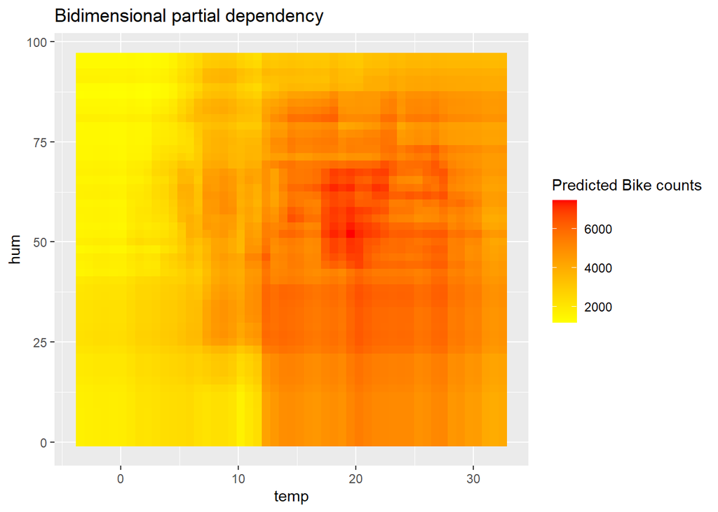

```r
ggplot(pdp_data, aes(x = temp, y=hum, fill = yhat)) +
  geom_tile() +
  ggtitle('Bidimensional partial dependency') +
  scale_fill_gradient (low = 'yellow', high = 'red', name = 'Predicted Bike counts')
```

This bidimensional partial dependency graph displays how combined humidity and temperature affect the amount of rented bikes.

When temperature is between 17 and 22 (aprox.) and humidity is between 45 and 70 (aprox.) the highest results are produced.

Very low temperature and humidity produce te contrary effect: The reduction of the predicted bike counts.

Temperature itself above 12 (aprox) is also an indicator of good rented bikes results, as humidity behaves as better increaser of the bike counts if it has not got extreme values (under 25 or above 85 aprox.)

```r
# Load the dataset
data_houses <-read.csv("kc_house_data.csv")

rf_modelH <- randomForest(price ~ bedrooms + bathrooms + sqft_living + sqft_lot + floors + yr_built, data = data_houses)
```

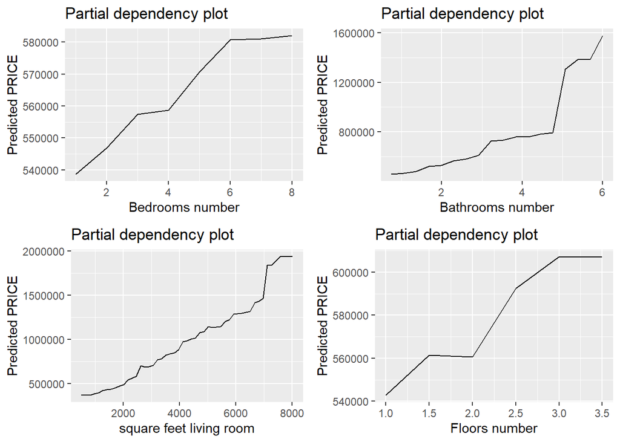

```r
# Same random seed, also for reproducibility reasons...
set.seed(123)

# Sample 1000 rows at random
sample_index <- sample(nrow(data_houses), 1000, replace = FALSE)
house_samples <- data_houses[sample_index, ]

rf_modelH2 <- randomForest(price ~ bedrooms + bathrooms + sqft_living + sqft_lot + floors + yr_built, data = house_samples)

# Create the four partial dependence plots with custom axis labels

bedrooms_pdp <- partial(rf_modelH2, pred.var = "bedrooms", plot = TRUE, plot.engine = "ggplot2") +
  ggtitle("Partial dependency plot") +
  xlab("Bedrooms number") +
  ylab("Predicted PRICE")

#bedrooms_pdp

bathrooms_pdp <- partial(rf_modelH2, pred.var = "bathrooms", plot = TRUE, plot.engine = "ggplot2") +
  ggtitle("Partial dependency plot") +
  xlab("Bathrooms number") +
  ylab("Predicted PRICE")

sqft_living_pdp <- partial(rf_modelH2, pred.var = "sqft_living", plot = TRUE, plot.engine = "ggplot2") +
  ggtitle("Partial dependency plot") +
  xlab("square feet living room") +
  ylab("Predicted PRICE")

floors_pdp <- partial(rf_modelH2, pred.var = "floors", plot = TRUE, plot.engine = "ggplot2") +
  ggtitle("Partial dependency plot") +
  xlab("Floors number") +
  ylab("Predicted PRICE")

# Combine the four plots into a single plot grid
grid.arrange(bedrooms_pdp, bathrooms_pdp, sqft_living_pdp, floors_pdp, nrow = 2, ncol = 2)
```

There is a positive relationship between the house bedrooms number and the predicted price, this is very clear for houses up to 3 bedrooms or between 4 and 6. As a curious thing, it looks like between 3 and 4 bedrooms and with more than 6, these extra rooms are not appreciated by the buyer as a fact to pay more money for those houses.

About the bathrooms number, there is also a logical positive relationship between the number of bathrooms and the predicted price. The house price increases specially for 5 or six bathrooms.

The square feet of the house has also a positive relationship with the house price and increases constantly with it. Above 7000 sqr. feet it is specially noticeable.

The floors number also affect positively to the house price up to 3 floors. It seems that houses with more floors (that should be very uncommon) are not increasing the final sales price.